# Natural Disaster Project Proposal

Sully, Adi, and Max

```r
library(tidyverse)
library(broom)
library(ggplot2)
library(leaflet)
library(sf)
library(leafsync)
```

## 1. Introduction

In our project, we will aim to assess the evolution of natural disaster intensity, frequency, and location of the 20th century. We will generate figures that outline how climate change has accelerated these events over the last century. Our dataset comes from a database called Kaggle that provides a handful of climate datasets that are free to download. It was collected by compiling a set of historical natural disaster records to create a comprehensive history of natural disasters during the 20th century. The observations in our data set are individual natural disasters while the variables are characteristics of each disaster including Year, Disaster.Group, Country, Deaths, etc. Our research question is: In what ways have natural disasters intensified over the last century?

## 2. Data

```r
natural_disasters <- read.csv(file = "../data/DCS_Project.csv")


glimpse(natural_disasters)
```

```
## Rows: 16,126
## Columns: 45
## $ Year                       <int> 1900, 1900, 1902, 1902, 1902, 1903, 1903, 1…
## $ Seq                        <int> 9002, 9001, 12, 3, 10, 6, 12, 3, 5, 3, 14, …
## $ Glide                      <chr> "", "", "", "", "", "", "", "", "", "", "",…
## $ Disaster.Group             <chr> "Natural", "Natural", "Natural", "Natural",…
## $ Disaster.Subgroup          <chr> "Climatological", "Climatological", "Geophy…
## $ Disaster.Type              <chr> "Drought", "Drought", "Earthquake", "Volcan…
## $ Disaster.Subtype           <chr> "Drought", "Drought", "Ground movement", "A…
## $ Disaster.Subsubtype        <chr> "", "", "", "", "", "", "", "", "", "", "",…
## $ Event.Name                 <chr> "", "", "", "Santa Maria", "Santa Maria", "…
## $ Country                    <chr> "Cabo Verde", "India", "Guatemala", "Guatem…
## $ ISO                        <chr> "CPV", "IND", "GTM", "GTM", "GTM", "CAN", "…
## $ Region                     <chr> "Western Africa", "Southern Asia", "Central…
## $ Continent                  <chr> "Africa", "Asia", "Americas", "Americas", "…
```

[output cut: 32 more lines]

## 3. Data analysis plan

1. In this project, we are looking specifically at how the severity of natural disasters has changed over the last century (1900-2000). Some of the variables that will be of interest to us are disaster subgroup, type, and subtype to categorize the disaster, while variables like region, year, and deaths will give us characteristics of the disaster. We plan to use mostly bar plots and scatterplots to visualize the dataset. Most of our variables are catagorical, so density plots with specific fill variables may be useful as well.
2. We don’t anticipate that any extra data will be necessary as there are enough columns in our dataset to create engaging figures.
3. Below are a handful of figures that will be helpful in our first assessment of the data

```r
summary(natural_disasters)
```

```
##       Year           Seq            Glide           Disaster.Group
##  Min.   :1900   Min.   :   1.0   Length:16126       Length:16126
##  1st Qu.:1989   1st Qu.:  93.0   Class :character   Class :character
##  Median :2001   Median : 270.0   Mode  :character   Mode  :character
##  Mean   :1997   Mean   : 714.8
##  3rd Qu.:2011   3rd Qu.: 486.0
##  Max.   :2021   Max.   :9881.0
##
##  Disaster.Subgroup  Disaster.Type      Disaster.Subtype   Disaster.Subsubtype
##  Length:16126       Length:16126       Length:16126       Length:16126
##  Class :character   Class :character   Class :character   Class :character
##  Mode  :character   Mode  :character   Mode  :character   Mode  :character
##
##
##
##
##   Event.Name          Country              ISO               Region
##  Length:16126       Length:16126       Length:16126       Length:16126
##  Class :character   Class :character   Class :character   Class :character
##  Mode  :character   Mode  :character   Mode  :character   Mode  :character
##
##
##
##
##   Continent           Location            Origin          Associated.Dis
##  Length:16126       Length:16126       Length:16126       Length:16126
##  Class :character   Class :character   Class :character   Class :character
##  Mode  :character   Mode  :character   Mode  :character   Mode  :character
##
##
##
##
##  Associated.Dis2    OFDA.Response         Appeal          Declaration
##  Length:16126       Length:16126       Length:16126       Length:16126
##  Class :character   Class :character   Class :character   Class :character
##  Mode  :character   Mode  :character   Mode  :character   Mode  :character
##
##
##
##
```

[output cut: 41 more lines]

```
##  Min.   :        2        Min.   :  3.222   Length:16126
##  1st Qu.:     8300        1st Qu.: 45.693   Class :character
##  Median :    60000        Median : 68.415   Mode  :character
##  Mean   :   724784        Mean   : 63.215
##  3rd Qu.:   317300        3rd Qu.: 84.253
##  Max.   :210000000        Max.   :100.000
##  NA's   :10881            NA's   :315
##  Admin1.Code        Admin2.Code        Geo.Locations
##  Length:16126       Length:16126       Length:16126
##  Class :character   Class :character   Class :character
##  Mode  :character   Mode  :character   Mode  :character
##
##
##
##
```

```r
str(natural_disasters)
```

```
## 'data.frame':    16126 obs. of  45 variables:
##  $ Year                      : int  1900 1900 1902 1902 1902 1903 1903 1904 1905 1905 ...
##  $ Seq                       : int  9002 9001 12 3 10 6 12 3 5 3 ...
##  $ Glide                     : chr  "" "" "" "" ...
##  $ Disaster.Group            : chr  "Natural" "Natural" "Natural" "Natural" ...
##  $ Disaster.Subgroup         : chr  "Climatological" "Climatological" "Geophysical" "Geophysical" ...
##  $ Disaster.Type             : chr  "Drought" "Drought" "Earthquake" "Volcanic activity" ...
##  $ Disaster.Subtype          : chr  "Drought" "Drought" "Ground movement" "Ash fall" ...
##  $ Disaster.Subsubtype       : chr  "" "" "" "" ...
##  $ Event.Name                : chr  "" "" "" "Santa Maria" ...
##  $ Country                   : chr  "Cabo Verde" "India" "Guatemala" "Guatemala" ...
##  $ ISO                       : chr  "CPV" "IND" "GTM" "GTM" ...
##  $ Region                    : chr  "Western Africa" "Southern Asia" "Central America" "Central America" ...
##  $ Continent                 : chr  "Africa" "Asia" "Americas" "Americas" ...
##  $ Location                  : chr  "Countrywide" "Bengal" "Quezaltenango, San Marcos" "" ...
```

[output cut: 31 more lines]

Summarizing the data allows us to visualize the dataset quickly.

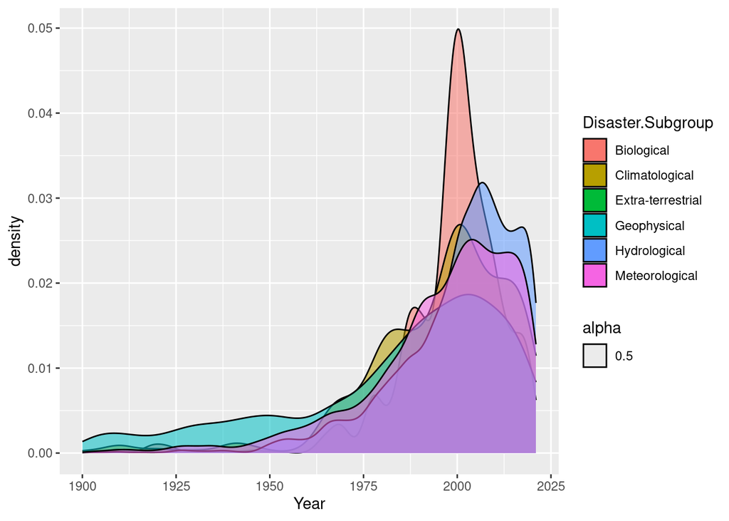

```r
ggplot(natural_disasters, mapping = aes(x = Year, fill = Disaster.Subgroup, alpha = 0.5)) +
  geom_density()
```

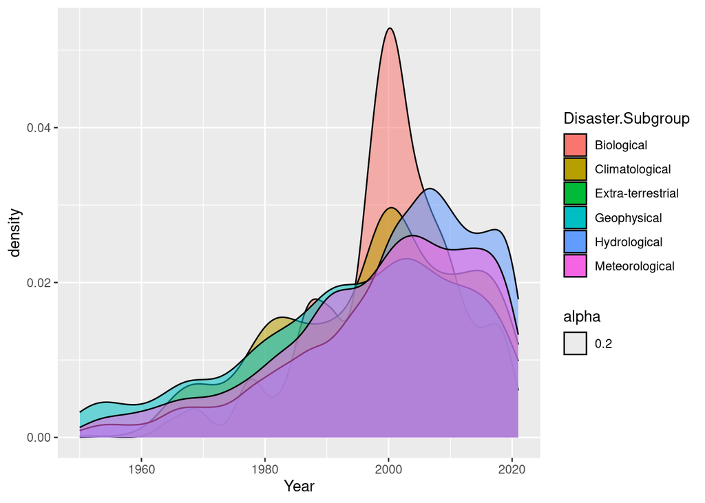

```r
filtered_data <- natural_disasters %>%
  filter(Year >= 1950 & Year <= 2025)

ggplot(filtered_data, mapping = aes(x = Year, fill = Disaster.Subgroup, alpha = 0.2, )) +
  geom_density()
```

```r
disaster_counts <- natural_disasters %>%
  count(Year, Disaster.Subgroup) %>%
  filter(Disaster.Subgroup != "Extra-terrestrial", Year >= 1940 & Year <= 2025)

pdf("Natural Disaster Heatmap.pdf")
ggplot(disaster_counts, aes(x = Year, y = Disaster.Subgroup, fill = n)) +
  geom_tile() +
  scale_fill_viridis_c() +
  labs(title = "Heatmap of Disasters by Subgroup and Year", x = "Year", y = "Disaster Subgroup") +
  theme_minimal()

dev.off()
```

```r
pdf("my_plot.pdf", width = 8, height = 6)
ggplot(natural_disasters, aes(x = Year)) +
  geom_histogram(binwidth = 5, fill = "skyblue", color = "black") +
  facet_wrap(~ Disaster.Subgroup) +
  labs(title = "Disaster Years by Subgroup", x = "Year", y = "Count") +
  theme_minimal()
pdf()
```

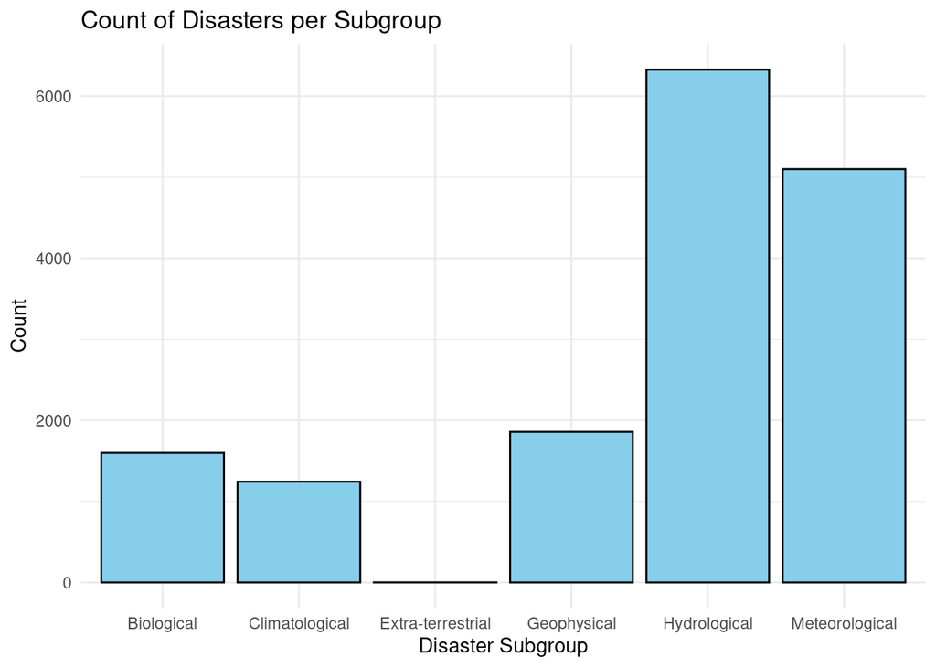

```r
ggplot(natural_disasters, aes(x = Disaster.Subgroup)) +
  geom_bar(fill = "skyblue", color = "black") +
  labs(title = "Count of Disasters per Subgroup", x = "Disaster Subgroup", y = "Count") +
  theme_minimal()
```

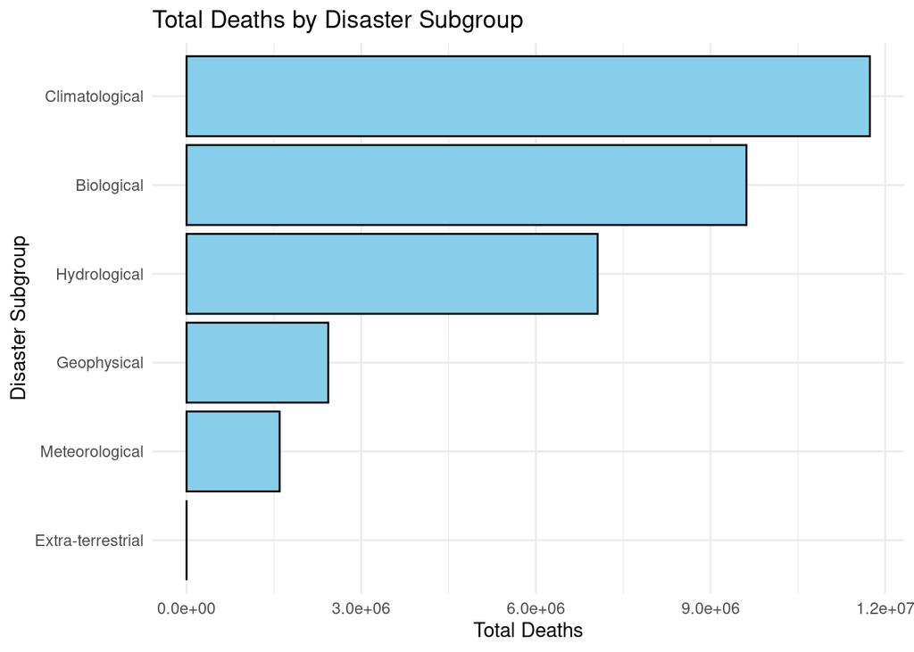

```r
death_by_subgroup <- natural_disasters %>%
  group_by(Disaster.Subgroup) %>%
  summarise(Total.Deaths = sum(Total.Deaths, na.rm = TRUE))

# Create bar plot
ggplot(death_by_subgroup, aes(x = reorder(Disaster.Subgroup, Total.Deaths), y = Total.Deaths)) +
  geom_bar(stat = "identity", fill = "skyblue", color = "black") +
  labs(title = "Total Deaths by Disaster Subgroup", x = "Disaster Subgroup", y = "Total Deaths") +
  coord_flip() + # Flips the axis for better readability
  theme_minimal()
```

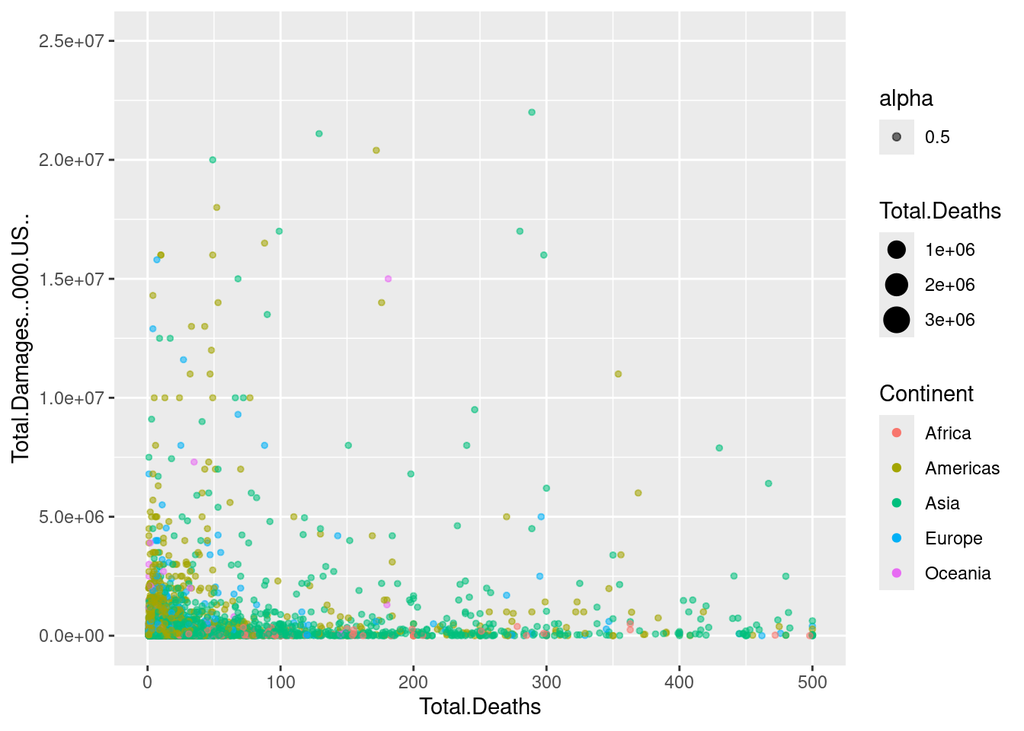

```r
ggplot(natural_disasters, mapping = aes(x = Total.Deaths, y = Total.Damages...000.US.., colour = Continent, size = Total.Deaths, alpha = 0.5)) +
  geom_point() +
   xlim(min_value = 0, max_value = 500)+
   ylim(min_value = 0, max_value = 2.5e+07)
```

```r
## check out https://rstudio.github.io/leaflet/articles/showhide.html

natural_disasters <- natural_disasters |>
  mutate(Latitude = as.numeric(str_extract(Latitude, pattern = "\\d+.\\d+")),
         Longitude = as.numeric(str_extract(Longitude, pattern = "\\d+.\\d+")))
glimpse(natural_disasters)
```

```
## Rows: 16,126
## Columns: 45
## $ Year                       <int> 1900, 1900, 1902, 1902, 1902, 1903, 1903, 1…
## $ Seq                        <int> 9002, 9001, 12, 3, 10, 6, 12, 3, 5, 3, 14, …
## $ Glide                      <chr> "", "", "", "", "", "", "", "", "", "", "",…
## $ Disaster.Group             <chr> "Natural", "Natural", "Natural", "Natural",…
## $ Disaster.Subgroup          <chr> "Climatological", "Climatological", "Geophy…
## $ Disaster.Type              <chr> "Drought", "Drought", "Earthquake", "Volcan…
## $ Disaster.Subtype           <chr> "Drought", "Drought", "Ground movement", "A…
## $ Disaster.Subsubtype        <chr> "", "", "", "", "", "", "", "", "", "", "",…
## $ Event.Name                 <chr> "", "", "", "Santa Maria", "Santa Maria", "…
## $ Country                    <chr> "Cabo Verde", "India", "Guatemala", "Guatem…
## $ ISO                        <chr> "CPV", "IND", "GTM", "GTM", "GTM", "CAN", "…
## $ Region                     <chr> "Western Africa", "Southern Asia", "Central…
## $ Continent                  <chr> "Africa", "Asia", "Americas", "Americas", "…
```

[output cut: 32 more lines]

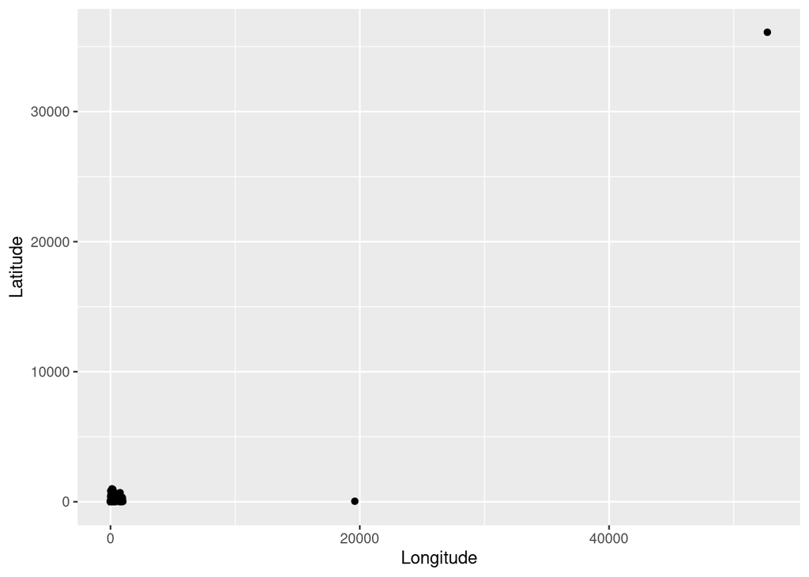

```r
ggplot(natural_disasters) +
  geom_point(aes(x = Longitude, y = Latitude))
```

```r
leaflet(natural_disasters) %>%
      addProviderTiles(providers$OpenStreetMap) %>%
  setView(lng = 0, lat = 0, zoom = 5) %>%
      addCircleMarkers(lng = ~Longitude, lat = ~Latitude, label = ~`Disaster.Type`)#, clusterOptions = markerClusterOptions())
```

[interactive chart not shown]

## 4. Data Ethics Review

Limitations in Data Sources:

Our data comes from an open source website called Kaggle that provides datasets for download. Since our dataset is advertised as being a comprehensive log of all natural disasters from 1900-2021, there are plenty of opportunities for our data to exclude disasters or inaccurately record certain metrics. Additionally, much of the data was collected in a time when the technology we use to monitor these disasters wasn’t quite what it is these days. This means that it is important to consider the difference in cost of damages, the possibility that some disasters were missed, or the chance that undeveloped areas of the world may have fatalities underestimated.

Positive Effects on People:

It’s possible that our project will be able to help us identify locations where people are most at risk of natural disasters in the future. Additionally, some of the world’s most marginalized communities are disproportionately impacted by climate change. Our study could illuminate areas that are in greatest need of support.

Negative Effects on People:

The same way that identify at risk locations might help illuminate the areas of the world that are at risk moving forward, underestimating the severity or frequency of disasters in certain areas could categorize areas as safe when they are not. Again, undeveloped areas of the world likely see their natural disasters underestimated, while areas of the world that have the resources to monitor and clean up after a disaster will have their damages recorded accurately.

Minimising Negative Impact:

Since this dataset might have omissions or misrepresentations, it is our responsibility to be on the lookout for patterns or errors that may have ended up in our figures. It would be useful to cross reference some of our data with records from other sources. In regards to damage costs, it would make sense to convert some of the early estimates to the 2025 USD scale, as the economy worked on a much smaller scale 100 years ago.